# Multiple RSF’s with Fisher data

John Fieberg & Johannes Signer

**Purpose**: demonstrate methods for analyzing data from multiple animals, allowing for multiple random slopes.

**NOTE** the mixed models here take considerable time to run (you may want to use caching to speed up if you plan to run multiple times). Change the following line, below, to enable caching: opts_chunk$set(fig.width=12,fig.height=4.5, error=TRUE,cache = FALSE).

#### Preamble

Load libraries

```r
library(glmmTMB)
library(tidyverse)
library(raster)
library(survival)
library(TwoStepCLogit)
library(amt)
library(here)
library(broom)
library(tictoc)
library(glmmTMB)
options(width=165)
knitr::opts_chunk$set(fig.width=12,fig.height=4.5, error=TRUE)
```

Record time for running all code

```r
tic("total")
```

Load the fisher data

```r
dat <- read_csv(here("Resource-and-Step-Selection-Analyses/Data", "fisher_data.csv")) %>%
  filter(id %in% c(1465, 1466, 1072, 1078, 1016, 1469))
```

We will make use of nested data frames in R, which will allow us to apply functions separately to data from each individual using the map functions in the Purr pacakge. If you are unfamiliar with `purrr` syntax, may want to view one or more of the tutorials, below, or make use of the [purrr cheat sheet](https://github.com/rstudio/cheatsheets/blob/master/purrr.pdf).

- http://www.rebeccabarter.com/blog/2019-08-19_purrr/
- https://www.r-bloggers.com/2020/05/one-stop-tutorial-on-purrr-package-in-r/
- https://jennybc.github.io/purrr-tutorial/index.html

```r
dat_all <- dat %>% nest(data=c(x,y,t))
dat_all$sex <- c("f", "f", "f", "m", "m", "m")
```

Include sex of each animal and create tracks with an appropriate coordinate reference system using the amt package

```r
dat_all <- dat_all %>%
  mutate(trk = map(data, function(d) {
    make_track(d, x, y, t, crs = 4326) %>%
      transform_coords(crs_to = 5070)
  }))
dat_all
```

```
## # A tibble: 6 × 4
##      id data                 sex   trk
##   <dbl> <list>               <chr> <list>
## 1  1072 <tibble [1,349 × 3]> f     <trck_xyt [1,349 × 3]>
## 2  1465 <tibble [3,004 × 3]> f     <trck_xyt [3,004 × 3]>
## 3  1466 <tibble [1,501 × 3]> f     <trck_xyt [1,501 × 3]>
## 4  1078 <tibble [1,638 × 3]> m     <trck_xyt [1,638 × 3]>
## 5  1469 <tibble [2,436 × 3]> m     <trck_xyt [2,436 × 3]>
## 6  1016 <tibble [8,958 × 3]> m     <trck_xyt [8,958 × 3]>
```

Summarize sampling rates,

```r
dat_all %>% mutate(sr = map(trk, summarize_sampling_rate)) %>%
  dplyr::select(id, sr) %>% unnest(cols=c(sr))
```

```
## # A tibble: 6 × 10
##      id   min    q1 median  mean    q3   max    sd     n unit
##   <dbl> <dbl> <dbl>  <dbl> <dbl> <dbl> <dbl> <dbl> <int> <chr>
## 1  1072 3.92   9.8   10.0  20.7  10.3  1650.  95.2  1348 min
## 2  1465 0.4    1.97   2.03  8.93  3.98 1080.  48.1  3003 min
## 3  1466 0.417  1.97   2.07 15.7   4.08 2167. 104.   1500 min
## 4  1078 1.35   9.78  10.0  21.7  10.3  2111.  87.2  1637 min
## 5  1469 0.417  1.97   2.17 13.3   5.42 2889.  90.2  2435 min
## 6  1016 0.1    1.93   2.03  8.04  2.57 1209.  44.0  8957 min
```

10 minutes seems to appropriate for all animals. Resample the track to 10 minutes with a tolerance of 2 minutes.

```r
dat1 <- dat_all %>% mutate(dat_clean = map(trk, ~ {
  .x %>% track_resample(rate = minutes(10), tolerance = seconds(120))
}))
```

Read in data layers

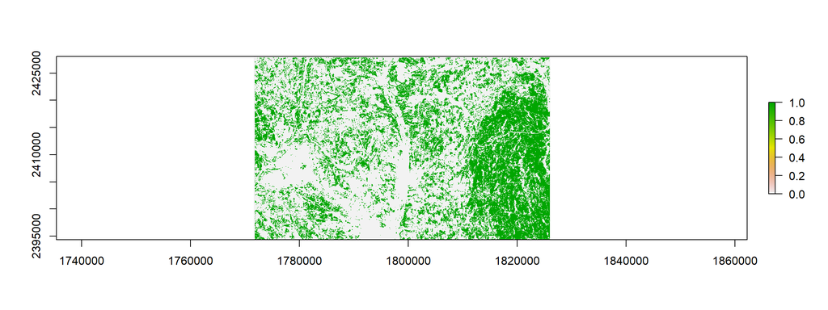

```r
elevation <- raster(here("Resource-and-Step-Selection-Analyses/Data/elevation/", "ASTER ASTGTM2 Elevation-20100101120000000-0-0.tif"))
landuse <- raster(here("Resource-and-Step-Selection-Analyses/Data/landuse", "landuse_study_area.tif"))
popden <- raster(here("Resource-and-Step-Selection-Analyses/Data/pop_den", "pop_den.tif"))
elevation[] <- (elevation[] - mean(elevation[], na.rm = TRUE))/sd(elevation[], na.rm = TRUE)
popden[] <- (popden[] - mean(popden[], na.rm = TRUE))/sd(popden[], na.rm = TRUE)

landuse <- raster::projectRaster(landuse, crs = "+init=epsg:5070")
elevation <- raster::projectRaster(elevation, crs = "+init=epsg:5070")
popden <- raster::projectRaster(popden, crs = "+init=epsg:5070")

forest <- raster::match(landuse, 41:43, nomatch = 0) > 0
raster::plot(forest)
```

```r
names(elevation)<-"elevation"
names(forest)<-"forest"
names(popden)<-"popden"
```

# Resource Selection Functions (RSF)

## Data development for RSF

Now start with an RSF by creating random points per animal within the animal’s MCP

```r
dat_rsf <- dat1 %>% mutate(rp = map(dat_clean, ~ .x %>% random_points() %>%
                                      extract_covariates(forest) %>%
                                      extract_covariates(elevation) %>%
                                      extract_covariates(popden))) %>%
                                      unnest(rp) %>%
                                      dplyr::select(id, sex, case_, elevation, popden, forest)
```

Change id column, to 1:6

```r
dat_rsf$id <- as.numeric(factor(dat_rsf$id))
```

Make response numeric (required for INLA)

```r
dat_rsf$y <- as.numeric(dat_rsf$case_)
dat_rsf$forest <- as.numeric(dat_rsf$forest)
```

We use a weighted likelihood for to fit the RSF. To this end, we need to create a variable for the weights, where used points (`case_ = TRUE`) keep weight 1, and available points (`case_ = FALSE`) obtain a large weight $W$ (here $W=1000$):

```r
dat_rsf$w <- 1000^(1 - dat_rsf$case_)
```

### Individual fits

Lets start by fitting “full” models to individuals and then look to see if coeficients are correlated (high values of one coefficient correspond to high/low values of another coefficient)

```r
rsffits <- dat_rsf %>% nest(data=!c(id,sex)) %>%
  mutate(mod = map(data, function(x){glm(case_ ~  forest + elevation + popden,
                                         data = x, weight=w,family = binomial)}))
```

Now, summarize fits to individual animals

```r
rsffits2 <- rsffits %>%
  dplyr::mutate(tidy = purrr::map(mod, broom::tidy),
                n = purrr::map(data, nrow) %>% simplify()) %>%
  unnest(tidy) %>% dplyr::select(-c(data, mod))
rsffits2
```

```
## # A tibble: 24 × 8
##       id sex   term        estimate std.error statistic  p.value     n
##    <dbl> <chr> <chr>          <dbl>     <dbl>     <dbl>    <dbl> <int>
##  1     2 f     (Intercept) -8.46       0.486   -17.4    1.07e-67 14828
##  2     2 f     forest       1.03       0.0601   17.2    1.78e-66 14828
##  3     2 f     elevation    1.54       0.520     2.96   3.05e- 3 14828
##  4     2 f     popden       0.163      0.0786    2.07   3.81e- 2 14828
##  5     4 f     (Intercept)  1.75       0.945     1.86   6.34e- 2 11132
##  6     4 f     forest       0.211      0.0668    3.16   1.58e- 3 11132
##  7     4 f     elevation   13.0        1.11     11.7    1.38e-31 11132
##  8     4 f     popden      -0.286      0.0740   -3.86   1.13e- 4 11132
##  9     5 f     (Intercept)  4.38       2.84      1.54   1.23e- 1  5599
## 10     5 f     forest      -0.00316    0.114    -0.0277 9.78e- 1  5599
## # ℹ 14 more rows
```

We can do statistics on statistics now

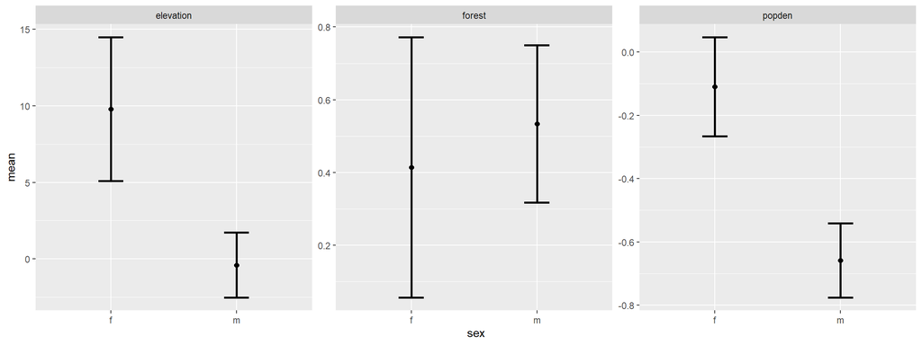

```r
se<-function(x){sqrt(var(x))/length(x)}
statsonstats<-rsffits2 %>% group_by(sex, term) %>%
  filter(term %in% c("elevation", "forest", "popden"))%>%
  summarize(mean=mean(estimate), se=se(estimate)) %>%
  mutate(up=mean+1.96*se, low=mean-1.96*se)

ggplot(statsonstats, aes(x=sex, y=mean))+
  geom_point(size=2) +
  geom_errorbar(aes(ymin=low, ymax=up),  width=0.2, size=1)+
  facet_wrap(~term, scales="free")
```

Keep just the estimates for later comparisons

```r
rsf_coefs<-rsffits2 %>%
  dplyr::select(-(std.error:p.value))

rsf_coefs_wide <- rsf_coefs %>%
  pivot_wider(., names_from=term, values_from=estimate)
```

Explore coefficients using a pair plot

```r
my_fn <- function(data, mapping, ...){
  p <- ggplot(data = data, mapping = mapping) +
    geom_point() +
    geom_smooth(method=lm, fill="blue", color="blue", ...)
  p
}
```

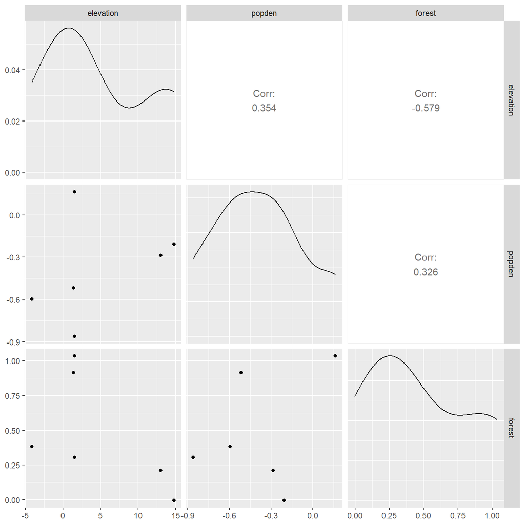

```r
rsf_coefs_wide %>% dplyr::select(elevation, popden, forest) %>%
   GGally::ggpairs(.)
```

### glmmTMB independent random slopes model

Process:

1. Set up model, but do not fit
2. Set random intercept variance to large fixed value, set other variance components to 0
3. Fit the model THis is the model we’d like to fit (where coefficients may be correlated), but you will wait a long time. And, it requires too many variance parameters for the small number of individuals

```r
tic("mixed mod")
fisher.tmp <- glmmTMB(case_ ~ elevation + forest + popden -1 + (1|id) +
                        (0 + elevation|id) + (0 + popden |id) +(0 +forest | id),
                      family=binomial(), data = dat_rsf,
                      doFit=FALSE, weights = w)
```

Set variance of random intercept to 10^6

```r
fisher.tmp$parameters$theta[1] <- log(1e3)
nvarparm<-length(fisher.tmp$parameters$theta)
fisher.tmp$mapArg <- list(theta=factor(c(NA,1:(nvarparm-1))))
fisher.rsf.ind <- glmmTMB:::fitTMB(fisher.tmp)
summary(fisher.rsf.ind)
```

```
##  Family: binomial  ( logit )
## Formula:          case_ ~ elevation + forest + popden - 1 + (1 | id) + (0 + elevation |      id) + (0 + popden | id) + (0 + forest | id)
## Data: dat_rsf
## Weights: w
##
##      AIC      BIC   logLik deviance df.resid
## 166969.9 167026.4 -83479.0 166957.9    90975
##
## Random effects:
##
## Conditional model:
##  Groups Name        Variance  Std.Dev.
##  id     (Intercept) 1.000e+06 1000.0000
##  id.1   elevation   4.005e+01    6.3283
##  id.2   popden      1.014e-01    0.3184
##  id.3   forest      1.333e-01    0.3651
## Number of obs: 90981, groups:  id, 6
##
## Conditional model:
##           Estimate Std. Error z value Pr(>|z|)
## elevation   4.3053     2.6446   1.628  0.10353
## forest      0.4801     0.1520   3.159  0.00159 **
## popden     -0.4032     0.1369  -2.945  0.00323 **
## ---
## Signif. codes:  0 '***' 0.001 '**' 0.01 '*' 0.05 '.' 0.1 ' ' 1
```

```r
toc()
```

```
## mixed mod: 13.08 sec elapsed
```

### Comparisons

Compare fixed effects (above) to mean coefficient from individual fits. These are quite similar.

```r
# MEAN COEFFICIENT FROM INDIVIDUAL FITS
rsf_coefs %>% filter(term!="(Intercept)") %>%
  group_by(term) %>%
  summarize(mean=mean(estimate), se.mean=sd(estimate)/sqrt(n()))
```

```
## # A tibble: 3 × 3
##   term        mean se.mean
##   <chr>      <dbl>   <dbl>
## 1 elevation  4.69    3.05
## 2 forest     0.474   0.167
## 3 popden    -0.384   0.145
```

```r
# POPULATION MEAN COEFFICIENT FROM MIXED MODEL
summary(fisher.rsf.ind)$coef$cond
```

```
##             Estimate Std. Error   z value    Pr(>|z|)
## elevation  4.3052720  2.6445563  1.627975 0.103530156
## forest     0.4800511  0.1519857  3.158528 0.001585682
## popden    -0.4032046  0.1369234 -2.944745 0.003232208
```

Compare variance of individual esimtates to variance component from mixed model. Note, the variance of the individual coefficients will be larger (too big) since it includes true variability and sampling variability.

```r
# VARIANCE OF COEFFICIENTS FROM INDIVIDUAL FITS
rsf_coefs %>% filter(term!="(Intercept)") %>%
  group_by(term) %>%
  summarize(var_elev=var(estimate), sd_elev=sd(estimate))
```

```
## # A tibble: 3 × 3
##   term      var_elev sd_elev
##   <chr>        <dbl>   <dbl>
## 1 elevation   55.9     7.48
## 2 forest       0.168   0.410
## 3 popden       0.126   0.355
```

```r
# VARIANCE COMPONENT FROM MIXED MODEL
summary(fisher.rsf.ind)$varcor
```

```
##
## Conditional model:
##  Groups Name        Std.Dev.
##  id     (Intercept) 1000.00000
##  id.1   elevation      6.32825
##  id.2   popden         0.31840
##  id.3   forest         0.36511
```

Look at individual coefficients

```r
# COEFFICIENTS FROM INDIVIDUAL FITS
rsf_coefs2 <- rsf_coefs %>% filter(term!="(Intercept)") %>% arrange(term, id)
rsf_coefs2$method<-"indiv_fits"
rsf_coefs2<-rsf_coefs2 %>%
  rename(Estimate=estimate)%>%
  dplyr::select(c(id, term, Estimate, method))

# COEFFICIENTS FROM MIXED MODEL
mixed_coefs <- coef(fisher.rsf.ind)$cond$id[,-1]
mixed_coefs$id <- rownames(mixed_coefs)
mixed_coefs <- mixed_coefs %>%
  pivot_longer(c('elevation', 'forest', 'popden'), names_to="term", values_to="Estimate")
mixed_coefs$method<-"Mixed"
```

### Plot results

Individual estimates

```r
allests<-rbind(mixed_coefs, rsf_coefs2)
```

Dataset with mean coefficients

```r
betas1<-rsf_coefs %>%
  filter(term!="(Intercept)") %>%
  group_by(term) %>%
  summarize(mean=mean(estimate))

betas1$method="indiv_fits"

# POPULATION MEAN COEFFICIENT FROM MIXED MODEL
betas2<-data.frame(mean=summary(fisher.rsf.ind)$coef$cond[,1])
betas2$method<-"Mixed"
betas2$term<-c("elevation", "forest", "popden")
```

Now, get asympototic normal-based CI for individual fits

```r
rsf_coefs.se<-rsffits2  %>% filter(term!="(Intercept)") %>%
  mutate(conf.high = estimate + 1.96*std.error,
         conf.low = estimate - 1.96*std.error,
         method="indiv_fits") %>%
  rename(Estimate=estimate) %>%
  dplyr::select(id, term, Estimate, method, conf.high, conf.low)
class(rsf_coefs.se)<-"data.frame"
```

Plot everything with nice colors Note that because of the large sample size, individual coefficients show very little shrinkage towards the overall mean.

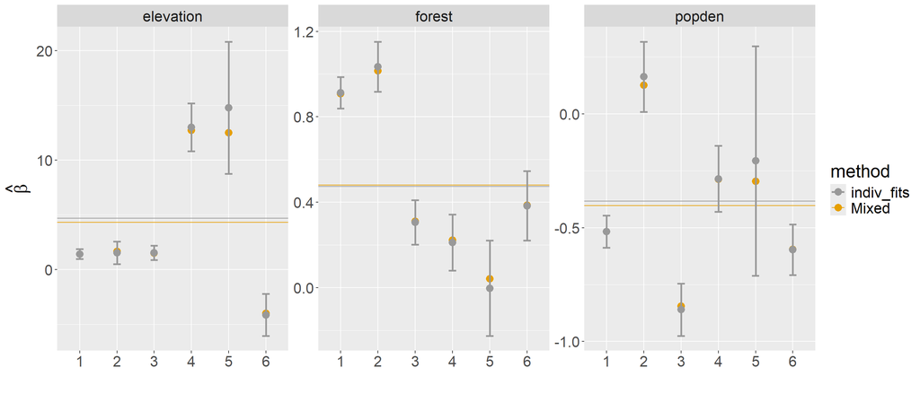

```r
cbp1 <- c("#999999", "#E69F00", "#56B4E9", "#009E73",
          "#F0E442", "#0072B2", "#D55E00", "#CC79A7")
ggplot(data=allests,
       aes(x=id, y=Estimate, col=method))+
  geom_point(size=3.5)+
  xlab("")+ylab(expression(hat(beta)))+facet_wrap(~term, scales="free") +
  geom_hline(aes(yintercept=mean, col=method), betas1)+
  geom_hline(aes(yintercept=mean, col=method), betas2)+
  scale_colour_manual(values=cbp1)+
  theme(text = element_text(size=20))+
  geom_errorbar( aes(x=id, ymin=conf.low, ymax=conf.high),
               width=0.2, size=1, data=rsf_coefs.se)
```

# SSF model

## Data prep for fitting step-selection functions

```r
dat1 <- dat_all %>% mutate(dat_clean = map(trk, ~ {
  .x %>% track_resample(rate = minutes(10), tolerance = seconds(120))
}))

dat_ssf <- dat1 %>%
  mutate(stps = map(dat_clean, ~ .x %>%
                      steps_by_burst() %>%
                      random_steps() %>%
                      extract_covariates(forest) %>%
                      extract_covariates(elevation) %>%
                      extract_covariates(popden))) %>%
  unnest(stps) %>%
  mutate(
    y = as.numeric(case_),
    id = as.numeric(factor(id)),
    step_id = paste0(id, step_id_, sep = "-")) %>%
    dplyr::select(id, sex, y, step_id, elevation, popden, forest)
  dat_ssf
```

```
## # A tibble: 56,694 × 7
##       id sex       y step_id elevation popden forest
##    <dbl> <chr> <dbl> <chr>       <dbl>  <dbl>  <dbl>
##  1     2 f         1 23-        -0.953 -0.238      1
##  2     2 f         0 23-        -0.947 -0.238      1
##  3     2 f         0 23-        -0.953 -0.238      1
##  4     2 f         0 23-        -0.953 -0.238      1
##  5     2 f         0 23-        -0.953 -0.238      1
##  6     2 f         0 23-        -0.968 -0.238      1
##  7     2 f         0 23-        -0.924 -0.238      1
##  8     2 f         0 23-        -0.953 -0.238      1
##  9     2 f         0 23-        -0.953 -0.238      1
## 10     2 f         0 23-        -0.953 -0.238      1
## # ℹ 56,684 more rows
```

### glmmTMB: random slopes model

The process is the same as for the mixed RSF:

1. Set up model, but do not fit
2. Set random intercept variance to large fixed value, set other variance components to 0
3. Fit the model

However, there are a few differences:

- we will use a Poisson likelihood rather than logistic
- we won’t need weights
- we will include fixed intercepts for each step_id

```r
tic("mixed ssf")
fisher.tmp <- glmmTMB(y ~ elevation + popden + forest -1 + (1|step_id) + (0 + elevation|id) +
                       (0 + popden|id) + (0+ forest |id), family=poisson(), data = dat_ssf,
                      doFit=FALSE)
```

Set variance of random intercept to 10^6

```r
fisher.tmp$parameters$theta[1] <- log(1e3)
nvarparm<-length(fisher.tmp$parameters$theta)
fisher.tmp$mapArg <- list(theta=factor(c(NA,1:(nvarparm-1))))
fisher.ssf <- glmmTMB:::fitTMB(fisher.tmp)
summary(fisher.ssf)
```

```
##  Family: poisson  ( log )
## Formula:          y ~ elevation + popden + forest - 1 + (1 | step_id) + (0 + elevation |      id) + (0 + popden | id) + (0 + forest | id)
## Data: dat_ssf
##
##      AIC      BIC   logLik deviance df.resid
## 106098.2 106151.9 -53043.1 106086.2    56688
##
## Random effects:
##
## Conditional model:
##  Groups  Name        Variance  Std.Dev.
##  step_id (Intercept) 1.000e+06 1000.0000
##  id      elevation   8.866e+00    2.9776
##  id.1    popden      4.330e-02    0.2081
##  id.2    forest      5.901e-02    0.2429
## Number of obs: 56694, groups:  step_id, 5154; id, 6
##
## Conditional model:
##           Estimate Std. Error z value Pr(>|z|)
## elevation   5.2874     1.6245   3.255  0.00114 **
## popden     -0.2071     0.1300  -1.593  0.11111
## forest      0.2848     0.1100   2.589  0.00964 **
## ---
## Signif. codes:  0 '***' 0.001 '**' 0.01 '*' 0.05 '.' 0.1 ' ' 1
```

```r
toc()
```

```
## mixed ssf: 7 sec elapsed
```

### Using Ts.Estim

```r
library(TwoStepCLogit)
tic("two-step")
twostep<-Ts.estim(formula = y ~  elevation+ popden+forest+
           strata(step_id) +cluster(id),data = dat_ssf, random = ~ elevation+popden+forest, all.m.1=F)
twostep
```

```
## Call:
## Ts.estim(formula = y ~ elevation + popden + forest + strata(step_id) +
##     cluster(id), data = dat_ssf, random = ~elevation + popden +
##     forest, all.m.1 = F)
##
## beta coefficients:
##             estimate        se
## elevation   5.658169  1.776678
## popden     -0.214247  0.150151
## forest      0.281889  0.120145
##
## D = estimate of the between-cluster variance-covariance matrix D,
##     for the random coefficients only:
##            elevation      popden      forest
## elevation   13.45612  0.00000000  0.00000000
## popden       0.00000  0.07508667  0.00000000
## forest       0.00000  0.00000000  0.07280897
```

```r
toc()
```

```
## two-step: 0.83 sec elapsed
```

### Individual fits

```r
ssffits <- dat_ssf %>% group_by(id) %>% nest %>%
  mutate(mod = map(data, function(x) (fit_issf(y ~ elevation + popden + forest + strata(step_id), data = x))))
```

Now, summarize fits to individual animals

```r
ssffits <- ssffits %>%
  mutate(tidy = map(mod, ~ broom::tidy(.x$model)),
         n = map_int(data, nrow))

ssffits %>% unnest(tidy) %>% filter(term!="(Intercept)") %>% print(., n=1000)
```

```
## # A tibble: 18 × 9
## # Groups:   id [6]
##       id data                  mod            term      estimate std.error statistic  p.value     n
##    <dbl> <list>                <list>         <chr>        <dbl>     <dbl>     <dbl>    <dbl> <int>
##  1     2 <tibble [13,002 × 6]> <fit_clgt [4]> elevation  2.36       1.14     2.08    3.76e- 2 13002
##  2     2 <tibble [13,002 × 6]> <fit_clgt [4]> popden     0.367      0.283    1.30    1.94e- 1 13002
##  3     2 <tibble [13,002 × 6]> <fit_clgt [4]> forest     0.636      0.0831   7.66    1.83e-14 13002
##  4     4 <tibble [5,753 × 6]>  <fit_clgt [4]> elevation 10.4        2.29     4.52    6.24e- 6  5753
##  5     4 <tibble [5,753 × 6]>  <fit_clgt [4]> popden    -0.259      0.211   -1.22    2.21e- 1  5753
##  6     4 <tibble [5,753 × 6]>  <fit_clgt [4]> forest     0.324      0.117    2.77    5.67e- 3  5753
##  7     5 <tibble [2,761 × 6]>  <fit_clgt [4]> elevation 15.8        5.98     2.65    8.16e- 3  2761
##  8     5 <tibble [2,761 × 6]>  <fit_clgt [4]> popden    -0.675      0.507   -1.33    1.83e- 1  2761
##  9     5 <tibble [2,761 × 6]>  <fit_clgt [4]> forest     0.415      0.205    2.02    4.34e- 2  2761
## 10     3 <tibble [14,487 × 6]> <fit_clgt [4]> elevation  5.84       1.32     4.41    1.03e- 5 14487
## 11     3 <tibble [14,487 × 6]> <fit_clgt [4]> popden    -0.275      0.205   -1.34    1.79e- 1 14487
## 12     3 <tibble [14,487 × 6]> <fit_clgt [4]> forest    -0.184      0.0771  -2.39    1.69e- 2 14487
## 13     6 <tibble [4,521 × 6]>  <fit_clgt [4]> elevation  7.33       3.41     2.15    3.16e- 2  4521
## 14     6 <tibble [4,521 × 6]>  <fit_clgt [4]> popden    -0.749      0.256   -2.92    3.51e- 3  4521
## 15     6 <tibble [4,521 × 6]>  <fit_clgt [4]> forest     0.204      0.139    1.46    1.44e- 1  4521
## 16     1 <tibble [16,170 × 6]> <fit_clgt [4]> elevation  1.16       0.954    1.22    2.23e- 1 16170
## 17     1 <tibble [16,170 × 6]> <fit_clgt [4]> popden    -0.00104    0.129   -0.00802 9.94e- 1 16170
## 18     1 <tibble [16,170 × 6]> <fit_clgt [4]> forest     0.334      0.0671   4.97    6.59e- 7 16170
```

Keep just coefficients for comparisons

```r
ssf_coefs<-ssffits %>% unnest(tidy) %>%
  dplyr::select(-(std.error:p.value))
```

### Comparisons

Compare fixed effects from mixed model and TS.Estim (above) to mean coefficient from individual fits

```r
# MEAN COEFFICIENT FROM INDIVIDUAL FITS
se<-function(x){sd(x)/sqrt(length(x))}
ssf_coefs %>% filter(term!="(Intercept)") %>%
  group_by(term) %>%
  summarize(mean=mean(estimate), se=se(estimate))
```

```
## # A tibble: 3 × 3
##   term        mean    se
##   <chr>      <dbl> <dbl>
## 1 elevation  7.15  2.21
## 2 forest     0.288 0.111
## 3 popden    -0.265 0.170
```

```r
# POPULATION MEAN COEFFICIENT FROM MIXED MODEL
summary(fisher.ssf)$coef$cond
```

```
##             Estimate Std. Error   z value    Pr(>|z|)
## elevation  5.2873544  1.6245500  3.254658 0.001135290
## popden    -0.2071290  0.1300049 -1.593241 0.111106223
## forest     0.2847529  0.1100062  2.588516 0.009639035
```

```r
# POPULATION MEAN COEFFICIENT FROM TWO-STEP (TS.Estim)
twostep$beta
```

```
##  elevation     popden     forest
##  5.6581685 -0.2142465  0.2818891
```

Compare variance of individual esimtates to variance component from mixed model.

```r
# VARIANCE OF COEFFICIENTs FROM INDIVIDUAL FITS
ssf_coefs %>% filter(term!="(Intercept)") %>%
  group_by(term) %>%
  summarize(var_elev=var(estimate), sd_elev=sd(estimate))
```

```
## # A tibble: 3 × 3
##   term      var_elev sd_elev
##   <chr>        <dbl>   <dbl>
## 1 elevation  29.2      5.40
## 2 forest      0.0742   0.272
## 3 popden      0.174    0.418
```

```r
# VARIANCE OF COEFFICIENTs FROM MIXED MODEL
summary(fisher.ssf)$varcor #var
```

```
##
## Conditional model:
##  Groups  Name        Std.Dev.
##  step_id (Intercept) 1000.00000
##  id      elevation      2.97763
##  id.1    popden         0.20809
##  id.2    forest         0.24292
```

```r
# VARIANCE OF COEFFICIENTs FROM TWO-STEP (TS.Estim)
sqrt(twostep$D) # sd
```

```
##           elevation    popden    forest
## elevation  3.668259 0.0000000 0.0000000
## popden     0.000000 0.2740195 0.0000000
## forest     0.000000 0.0000000 0.2698314
```

Look at individual coefficients

```r
# COEFFICIENTs FROM INDIVIDUAL FITS
ssf_coefs2 <- ssf_coefs %>% filter(term!="(Intercept)") %>% arrange(term, id)
ssf_coefs2$method<-"indiv_fits"
names(ssf_coefs2)[5]<-"Estimate"
ssf_coefs2<-ssf_coefs2 %>%
  dplyr::select(c(id, term, Estimate, method))

# COEFFICIENTs FROM MIXED MODEL
mixed_coefs <- coef(fisher.ssf)$cond$id[,-1]
mixed_coefs$id <- rownames(mixed_coefs)
mixed_coefs <- mixed_coefs %>%
  pivot_longer(c('elevation', 'forest', 'popden'), names_to="term", values_to="Estimate")
mixed_coefs$method<-"Mixed"


# COEFFICIENTS FROM TWO-STEP (TS.Estim)
twostepcoefs<-matrix(twostep$beta, nrow(twostep$r.effect), ncol(twostep$r.effect), byrow=TRUE)+twostep$r.effect
twostepcoefs<-as.data.frame(twostepcoefs)
twostepcoefs$method<-"two_step"
twostepcoefs$id<-rownames(twostep$r.effect)
twostepcoefs<-twostepcoefs %>%
  pivot_longer(c('elevation', 'popden','forest'), names_to="term", values_to="Estimate")%>%
  dplyr::select(c(id, term, Estimate, method))
```

### Plot results

Combine individual estimates

```r
allests<-rbind(mixed_coefs, ssf_coefs2,twostepcoefs)
```

Dataset with mean coefficients

```r
betas1<-ssf_coefs %>% filter(term!="(Intercept)") %>% group_by(term) %>%   summarize(mean=mean(estimate))
betas1$method="indiv_fits"

# POPULATION MEAN COEFFICIENT FROM MIXED MODEL
betas2<-data.frame(mean=summary(fisher.ssf)$coef$cond[,1])
betas2$method<-"Mixed"
betas2$term<-c("elevation", "popden", "forest")


# POPULATION MEAN COEFFICIENT FROM TWO-STEP (TS.Estim)
betas3<-data.frame(mean=twostep$beta, method=rep("two_step",3), term=c("elevation", "popden", "forest" ))
```

Now, get asympototic normal-based CI for individual fits

```r
ssf_coefs.se<-ssffits %>%   unnest(tidy)
ssf_coefs.se<-ssf_coefs.se %>% dplyr::select(-data) %>% dplyr::select(-mod)
ssf_coefs.se$conf.high<-ssf_coefs.se$estimate + 1.96*ssf_coefs.se$std.error
ssf_coefs.se$conf.low<-ssf_coefs.se$estimate - 1.96*ssf_coefs.se$std.error
class(ssf_coefs.se)<-"data.frame"
names(ssf_coefs.se)[4]<-"Estimate"
ssf_coefs.se<-ssf_coefs.se %>% filter(term!="(Intercept)")
ssf_coefs.se$method="indiv_fits"
```

Note here that a few coefficients for elevation and popD show considerable shrinkage. These are coefficients with large SEs as seen by inspecting the individual fits.

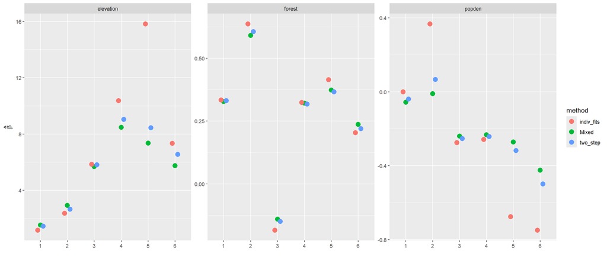

```r
ggplot(data=allests,
       aes(x=id, y=Estimate, col=method))+
  geom_point(size=3.5, position=position_dodge(width=0.3))+
  xlab("")+ylab(expression(hat(beta)))+facet_wrap(~term, scales="free")
```

With SEs and dropping the two-step method

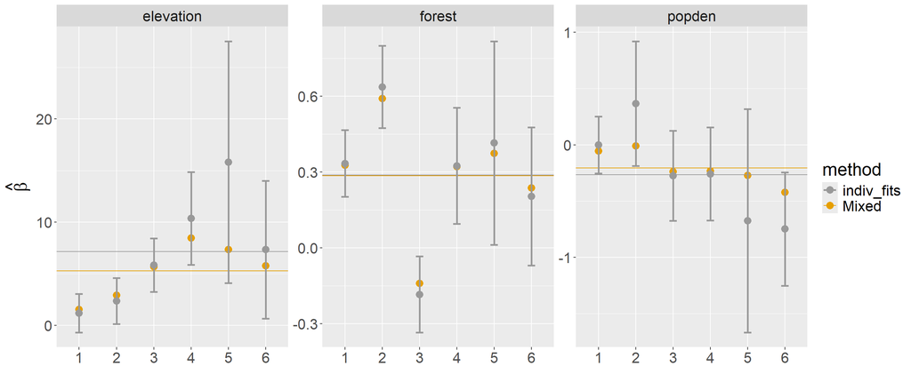

```r
ggplot(data=allests[allests$method!="two_step",],
       aes(x=id, y=Estimate, col=method))+
  geom_point(size=3.5)+
  xlab("")+ylab(expression(hat(beta)))+facet_wrap(~term, scales="free")+
  geom_hline(aes(yintercept=mean, col=method), betas1)+
  geom_hline(aes(yintercept=mean, col=method), betas2)+
  scale_colour_manual(values=cbp1)+
  theme(text = element_text(size=20))+
  geom_errorbar( aes(x=id, ymin=conf.low, ymax=conf.high),
                 width=0.2, size=1, data=ssf_coefs.se)
```

Total Elapsed time

```r
toc()
```

```
## total: 67.37 sec elapsed
```